# Model Diagnostics

Evaluating Model Assumptions

Ranadeep Daw

2024-10-15

## Why Diagnostics Matter?

- **Model diagnostics** are crucial for ensuring the validity of your regression model.
- Whenever you have some data on a response and one or more predictors, you will be able to create a model.
- However, diagnostics allow us to understand if the model assumptions hold or if the model is misleading.

## Overview of Regression Assumptions:

$$y_i =
\beta_0 + \beta_1 X_{1i} + \beta_2 X_{2i} + \ldots + \beta_p X_{pi} +
\epsilon_i$$

1. **Linearity**: the relationship between the independent variables and the dependent variable should be linear.
2. **Normality** of residuals with mean $0$ and same variance (**Homoscedasticity**).
3. **Multicollinearity**: the independent variables should not be too highly correlated.
4. **Outliers**: Not an assumption, but there should be no outlier in the data.

## Why They Matter:

- Violations of these assumptions can lead to:
  - biased estimates.
  - unreliable inferences.
  - incorrect uncertainty.

## Diagnostics 2: Test for Residual Normality.

- We assume that the errors/ residuals of a regression model ideally follow a normal distribution.
- How do we test for normality?
  - Step 1: Fit the model and see the residuals.
  - Step 2: **Visual Check:** Use a QQ-plot (Quantile-Quantile plot).
  - Step 3: **Formal statistical test:** Perform a Shapiro-Wilk test.

## QQ-plot for normality

- QQ-plot is a scatterplot between theoretical normal quantiles against the quantiles of the residuals.
- If the normality assumption is correct, the residual quantiles and the theoretical quantiles should be close.
- Look at the QQ-plot next. As long as most of the data are falling on the line, the normality assumption is fine.
- Note: **we may disagree on our conclusion**. You just have to conclude what you think from the plot.
- Syntax: $\texttt{plot(<model_name>, which=2)}$

## QQ-plot for normality

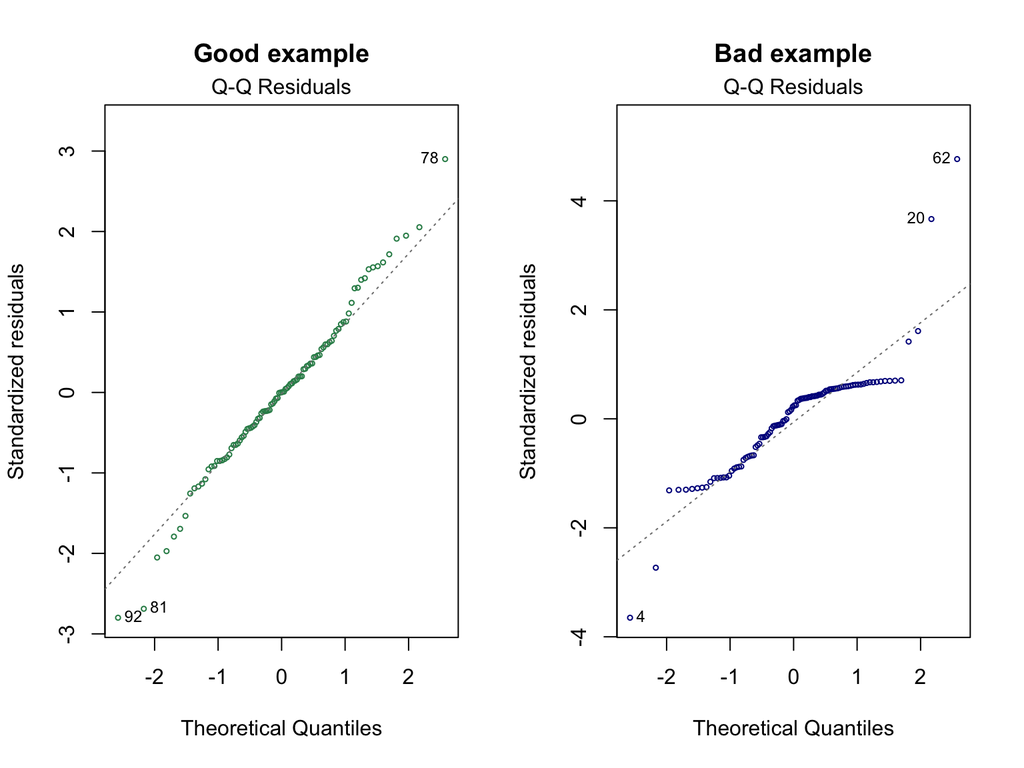

## Example

- Let’s do another linear regression model with $\texttt{mtcars}$ data.
- Use $\texttt{mpg}$ as predictor and $\texttt{wt}$, $\texttt{drat}$, and $\texttt{qsec}$ as predictors.

```r
mlr_model = lm(   mpg ~  wt + qsec + drat, data = mtcars)
mlr_model
```

```
##
## Call:
## lm(formula = mpg ~ wt + qsec + drat, data = mtcars)
##
## Coefficients:
## (Intercept)           wt         qsec         drat
##     11.3945      -4.3978       0.9462       1.6561
```

## QQ-plot

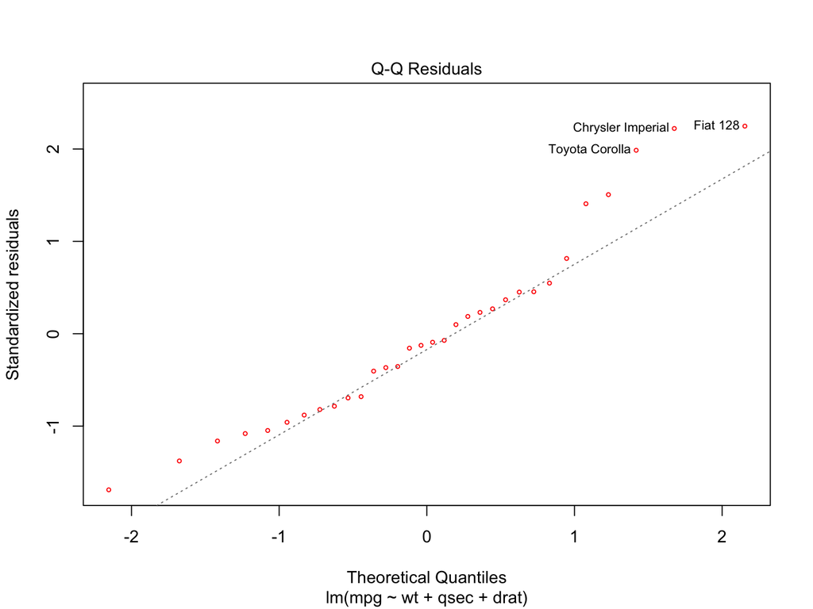

```r
plot(mlr_model, which = 2, cex = 0.5, col = "red")
```

## QQ-plot

- It seems that the observed quantiles are deviating a bit from the straight line, which ideally should not be the case under normality.
- So, just by eye checking, I am concluding here that the residuals don’t follow normality.
- **You may or may not agree with me.** That’s the problem with eye test. Hence we need more rigorous method of hypothesis testing.

## Shapiro-Wilk test

- This is a test to formally check if the residuals follow normality or not.
- The null hypothesis ($H_0$) is that the residual follows normal distribution.
- If the $p$-value is less than $\alpha$, then we reject the $H_0$ and conclude that normality assumption is violated.
- The syntax is the following:

```r
shapiro.test(residuals(<model_name>))
```

## Shapiro-Wilk (cont.)

```r
shapiro.test(residuals(mlr_model))
```

```
##
##  Shapiro-Wilk normality test
##
## data:  residuals(mlr_model)
## W = 0.94389, p-value = 0.09659
```

- Since $p$-value > $\alpha = 0.05$, I can’t reject the $H_0$ that residuals follow normality.
- Hence, my eye test from the previous part is not correct.

## Diagnostics 4: No outliers

- You should look at the residual-vs-fitted plot. Remember, the syntax is: $\texttt{plot(<model_name>, which=1)}$
- No residual point should stand out compared to others.
- We will only do an eye test. You can also do the boxplot to check outliers or do some formal testing procedures.

## Diagnostics 4

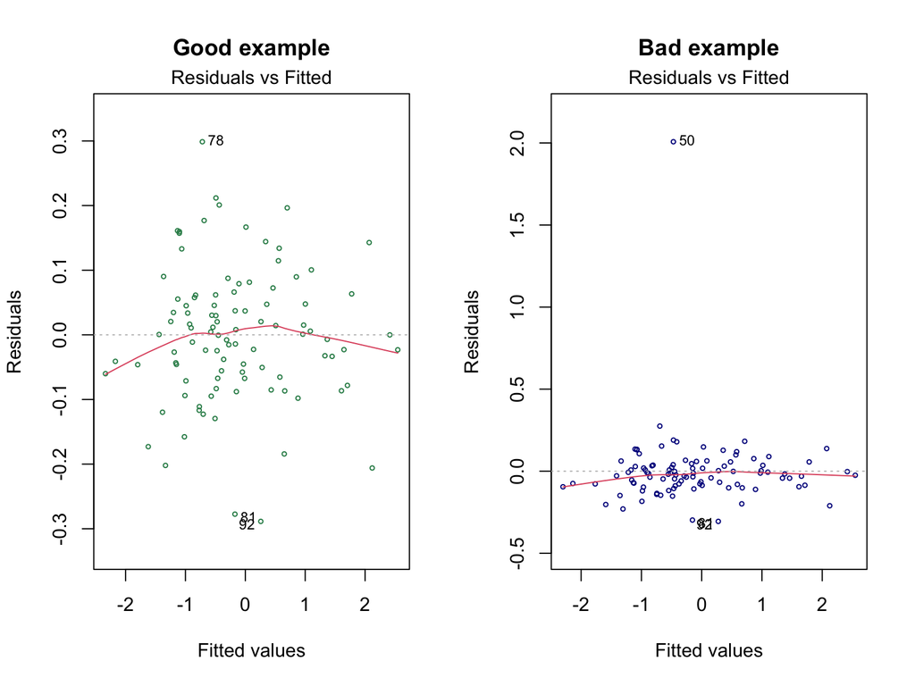

## Diagnostics 1: Linearity

- **Linearity** means that there is a straight-line relationship between the independent variables and the dependent variable.
- This assumption is crucial for interpreting regression coefficients meaningfully.

## How to Diagnose Linearity

1. **Scatterplot**: Should show a linear pattern. Anything else is violation of linearity.
2. **Residuals vs Fitted Plot**: Any clear pattern (e.g., a curve) suggests a violation of linearity.

## Example

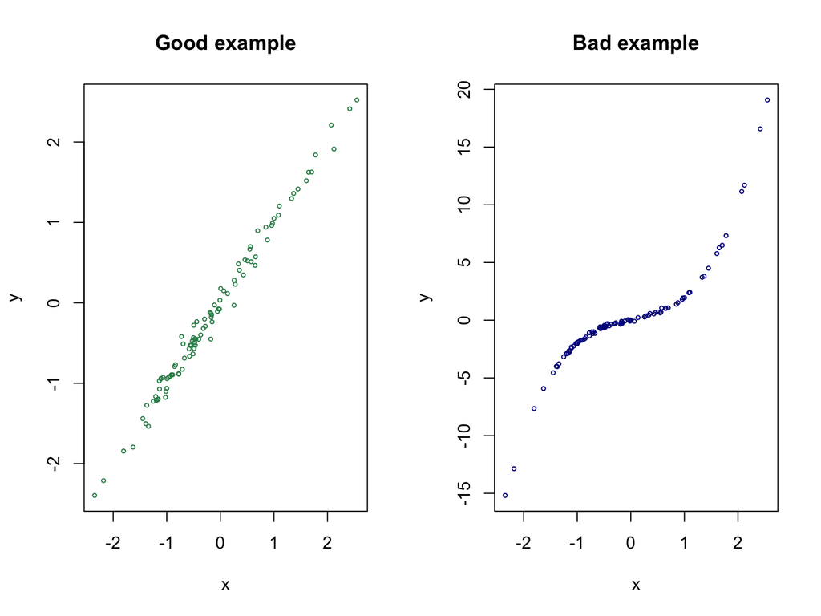

## Example: Residual vs Fitted plot

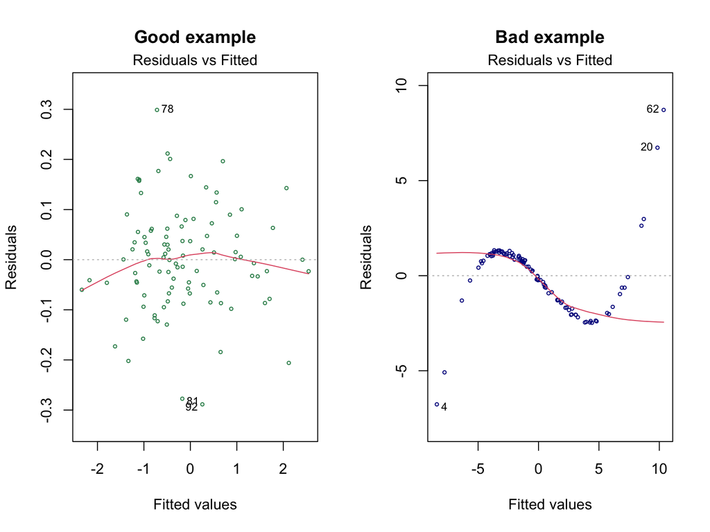

## Polynomial regression model

- When the relationship between predictors and the response variable is not linear, we can try to fit a polynomial regression model.
- Let’s try to fit our very first polynomial regression model with the $\texttt{mtcars}$ data.
- Let’s take $\texttt{mpg}$ as the response and the variable $\texttt{hp}$ as our predictor variable.

## Example: scatterplot

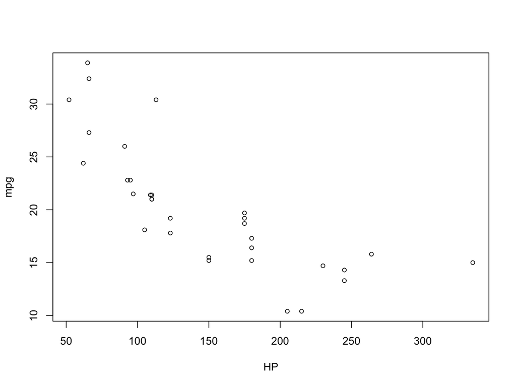

```r
data("mtcars")
HP = mtcars$hp
MPG = mtcars$mpg
plot(HP, MPG, xlabl = "hp", ylab = "mpg", cex = 0.8)
```

## Example: model

- Since there is a slight change in pattern before and after hp = 200, we may consider using a complicated model here.
- Let’s try to fit a quadratic model of the following form:

$$\text{mpg} = \beta_0 + \beta_1 \,
\text{hp} + \beta_2 \, \text{hp}^2 + \epsilon$$

## Example: In $\texttt{R}$

- In $\texttt{R}$, for a quadratic model, you have to specify

```r
<model_name> = lm(<y_column> ~ poly(<x_column>, 2), data = <data_name>)
```

- Example here:

```r
model_polynomial <- lm(mpg ~ poly(hp, 2), data = mtcars)
model_polynomial
```

```
##
## Call:
## lm(formula = mpg ~ poly(hp, 2), data = mtcars)
##
## Coefficients:
##  (Intercept)  poly(hp, 2)1  poly(hp, 2)2
##        20.09        -26.05         13.15
```

## Example: Model summary

```r
summary(model_polynomial) # See the summary table
```

```
##
## Call:
## lm(formula = mpg ~ poly(hp, 2), data = mtcars)
##
## Residuals:
##     Min      1Q  Median      3Q     Max
## -4.5512 -1.6027 -0.6977  1.5509  8.7213
##
## Coefficients:
##              Estimate Std. Error t value Pr(>|t|)
## (Intercept)    20.091      0.544  36.931  < 2e-16 ***
## poly(hp, 2)1  -26.046      3.077  -8.464 2.51e-09 ***
## poly(hp, 2)2   13.155      3.077   4.275 0.000189 ***
## ---
## Signif. codes:  0 '***' 0.001 '**' 0.01 '*' 0.05 '.' 0.1 ' ' 1
##
## Residual standard error: 3.077 on 29 degrees of freedom
## Multiple R-squared:  0.7561, Adjusted R-squared:  0.7393
## F-statistic: 44.95 on 2 and 29 DF,  p-value: 1.301e-09
```

## Example: Plot it

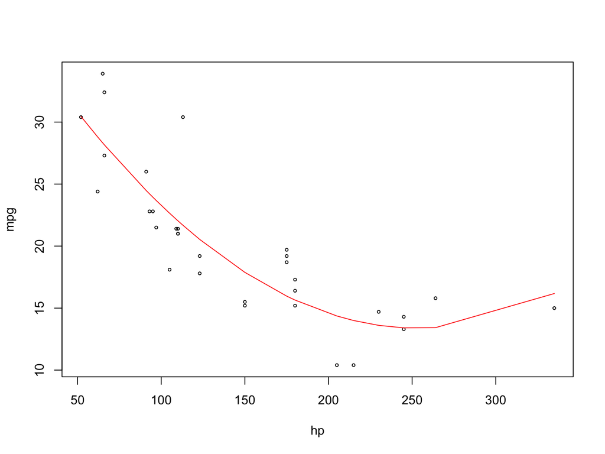

## Example: cont.

- **Question**: Is it a better model than the usual linear model:
  $$\text{mpg} = \beta_0 +
  \beta_1 \, \text{hp} + \epsilon?$$
- **Answer**: Let’s fit this simple model first.

```r
model_simple = lm( mpg ~ hp, data = mtcars)
model_simple
```

```
##
## Call:
## lm(formula = mpg ~ hp, data = mtcars)
##
## Coefficients:
## (Intercept)           hp
##    30.09886     -0.06823
```

## Example: See the summary table

```r
summary(model_simple) # See the new summary table
```

```
##
## Call:
## lm(formula = mpg ~ hp, data = mtcars)
##
## Residuals:
##     Min      1Q  Median      3Q     Max
## -5.7121 -2.1122 -0.8854  1.5819  8.2360
##
## Coefficients:
##             Estimate Std. Error t value Pr(>|t|)
## (Intercept) 30.09886    1.63392  18.421  < 2e-16 ***
## hp          -0.06823    0.01012  -6.742 1.79e-07 ***
## ---
## Signif. codes:  0 '***' 0.001 '**' 0.01 '*' 0.05 '.' 0.1 ' ' 1
##
## Residual standard error: 3.863 on 30 degrees of freedom
## Multiple R-squared:  0.6024, Adjusted R-squared:  0.5892
## F-statistic: 45.46 on 1 and 30 DF,  p-value: 1.788e-07
```

## Comparison

- As shown previously, we learnt to compare models using $3$ ways:
  - Backward elimination using $p$-value. Stop when all variables significant.
  - Backward elimination in $\texttt{R}$. Stops using the AIC criterion.
  - Adjusted $R^2$.
- Let’s try to compare the polynomial model with the linear model here.

## Backward elimination using $p$-value

- See the polynomial model coefficient table.

```
##              Estimate Std. Error t value  Pr(>|t|)
## (Intercept)   20.0906     0.5440 36.9311 < 2.2e-16 ***
## poly(hp, 2)1 -26.0456     3.0774 -8.4637 2.514e-09 ***
## poly(hp, 2)2  13.1546     3.0774  4.2746 0.0001889 ***
## ---
## Signif. codes:  0 '***' 0.001 '**' 0.01 '*' 0.05 '.' 0.1 ' ' 1
```

- Since all $p$-values < $\alpha$, the polynomial term is significant here.

## Backward elimination in $\texttt{R}$

- Let’s try the $\texttt{step}$ function from $\texttt{R}$ to see the final model.
- Recall that, the syntax is:

```r
backward_model = step(<full_model>, direction = "backward")
summary(backward_model)
```

- Here, full model is the polynomial one. So, let’s try our code.
- You will see next that the polynomial model is still favored here.

## Backward elimination in $\texttt{R}$

```r
backward_model = step(model_polynomial, direction = "backward")
summary(backward_model)
```

```
##
## Call:
## lm(formula = mpg ~ poly(hp, 2), data = mtcars)
##
## Residuals:
##     Min      1Q  Median      3Q     Max
## -4.5512 -1.6027 -0.6977  1.5509  8.7213
##
## Coefficients:
##              Estimate Std. Error t value Pr(>|t|)
## (Intercept)    20.091      0.544  36.931  < 2e-16 ***
## poly(hp, 2)1  -26.046      3.077  -8.464 2.51e-09 ***
## poly(hp, 2)2   13.155      3.077   4.275 0.000189 ***
## ---
## Signif. codes:  0 '***' 0.001 '**' 0.01 '*' 0.05 '.' 0.1 ' ' 1
##
## Residual standard error: 3.077 on 29 degrees of freedom
## Multiple R-squared:  0.7561, Adjusted R-squared:  0.7393
## F-statistic: 44.95 on 2 and 29 DF,  p-value: 1.301e-09
```

## Diagnostics 3: Multicollinearity

- **Multicollinearity** occurs when two or more independent variables or predictors are highly correlated among each-other.
- This makes it difficult to isolate the individual effects of each predictor on the dependent variable.
- It can lead to incorrect conclusions about the predictors.

## Detection of Multicollinearity

1. **Correlation Matrix:**
- Any high correlation between any two predictors suggests multicollinearity in the data.
2. **Variance Inflation Factor (VIF):**
- VIF measures how much the variance of a regression coefficient is inflated due to multicollinearity.
- A VIF value greater than a threshold (typically $5$ or $10$) indicates problematic multicollinearity.

## Example:

- Let’s fit another multiple linear regression model with $\texttt{mtcars}$ data.
- Use $\texttt{mpg}$ as predictor and $\texttt{wt}$, $\texttt{disp}$, and $\texttt{qsec}$ as predictors.

```r
mlr_model = lm(   mpg ~  wt + disp + qsec, data = mtcars)
mlr_model
```

```
##
## Call:
## lm(formula = mpg ~ wt + disp + qsec, data = mtcars)
##
## Coefficients:
## (Intercept)           wt         disp         qsec
##  19.7775576   -5.0344097   -0.0001279    0.9266492
```

## Example: Multicollinearity using Covariance matrix

- Let’s look at the covariance matrix next.

```r
cor(mtcars[c("wt", "disp", "qsec")])
```

```
##              wt       disp       qsec
## wt    1.0000000  0.8879799 -0.1747159
## disp  0.8879799  1.0000000 -0.4336979
## qsec -0.1747159 -0.4336979  1.0000000
```

- See that how highly $\texttt{wt}$ and $\texttt{disp}$ are correlated. This clearly suggests multicollinearity.

## Multicollinearity using VIF

- To calculate VIF, you have to install the $\texttt{car}$ package and use the function $\texttt{vif}$ from there.
- To check if $\texttt{car}$ package is installed, please go to the $\texttt{R}$ console and try:

```r
library("car")
```

- If it gives an error, it means the package is not installed. In that case, please try installing it by using:

```r
install.packages("car")
```

- **Please don’t install from a Rmd file. It doesn’t work.**

## Example: Multicollinearity using VIF (cont)

- Syntax:

```r
car::vif(<model_name>)
```

- Example:

```r
mlr_model = lm(   mpg ~  wt + disp + qsec, data = mtcars)
car::vif(mlr_model)
```

```
##       wt     disp     qsec
## 6.370710 7.607087 1.659492
```

## Interpretation of VIF

- If we follow the cutoff value of $5$, you’ll notice that both $\texttt{wt}$ and $\texttt{disp}$ have high VIF.
- This means that both $\texttt{wt}$ and $\texttt{disp}$ are highly correlated with a linrar comnbination of other variables, excluding themselves.

## How to Handle Multicollinearity?

1. **Do nothing:** You may do this when only prediction is of importance, but definitely not recommended when variable significance is needed.
2. **Remove or combine predictors:** Methods like Principal Component Analysis (PCA) combine predictors and create a new set of predictors that have no collinearity.
3. **Penalized regression**: Methods like Ridge and Lasso regression apply regularization to shrink the coefficients $\widehat{\beta}$ helping to reduce multicollinearity’s impact.

## Example 2[^1]

- Use the data on 20 individuals with high blood pressure from [here](https://online.stat.psu.edu/stat462/sites/onlinecourses.science.psu.edu.stat462/files/data/bloodpress/index.txt). The variables are:

| Description | Column Name |
| --- | --- |
| Blood pressure ( in mm Hg) | BP |
| Age (in years) | Age |
| Weight (in kg) | Weight |
| Body surface area (in sq m) | BSA |
| Duration of hypertension (in years) | Dur |
| Basal pulse (in beats per minute) | Pulse |
| Stress index | Stress |

## Cont.

- My following code downloads the data in a dataframe called $\texttt{bp_data}$, cleans it, and shows a snapshot of the data:

```r
bp_data = read.table(url("https://online.stat.psu.edu/stat462/sites/onlinecourses.science.psu.edu.stat462/files/data/bloodpress/index.txt"), header =TRUE)
bp_data[,1] = NULL
head(bp_data)
```

```
##    BP Age Weight  BSA Dur Pulse Stress
## 1 105  47   85.4 1.75 5.1    63     33
## 2 115  49   94.2 2.10 3.8    70     14
## 3 116  49   95.3 1.98 8.2    72     10
## 4 117  50   94.7 2.01 5.8    73     99
## 5 112  51   89.4 1.89 7.0    72     95
## 6 121  48   99.5 2.25 9.3    71     10
```

## Example 2:

1. We want to build a linear regression model with blood pressure as response and age, weight, body surface area, duration, pulse rate and/or stress level as predictors. Build the regression model.
2. Check if multicollinearity is present in the data using correlation coefficients. Take a cutoff of $\pm 0.65$.
3. Calculate the VIF of the model. Do you think there is multicollinearity in the data using a cutoff of $5$?

## Example 2: Q1

```r
my_model = lm(BP ~ Age + Weight + BSA + Dur + Pulse + Stress, data = bp_data)
summary(my_model)
```

```
##
## Call:
## lm(formula = BP ~ Age + Weight + BSA + Dur + Pulse + Stress,
##     data = bp_data)
##
## Residuals:
##      Min       1Q   Median       3Q      Max
## -0.93213 -0.11314  0.03064  0.21834  0.48454
##
## Coefficients:
##               Estimate Std. Error t value Pr(>|t|)
## (Intercept) -12.870476   2.556650  -5.034 0.000229 ***
## Age           0.703259   0.049606  14.177 2.76e-09 ***
## Weight        0.969920   0.063108  15.369 1.02e-09 ***
## BSA           3.776491   1.580151   2.390 0.032694 *
## Dur           0.068383   0.048441   1.412 0.181534
## Pulse        -0.084485   0.051609  -1.637 0.125594
## Stress        0.005572   0.003412   1.633 0.126491
## ---
## Signif. codes:  0 '***' 0.001 '**' 0.01 '*' 0.05 '.' 0.1 ' ' 1
##
## Residual standard error: 0.4072 on 13 degrees of freedom
## Multiple R-squared:  0.9962, Adjusted R-squared:  0.9944
## F-statistic: 560.6 on 6 and 13 DF,  p-value: 6.395e-15
```

## Example 2: Q2

```r
cor(bp_data[c("Age", "Weight", "BSA", "Dur", "Pulse", "Stress")])
```

```
##              Age     Weight        BSA       Dur     Pulse     Stress
## Age    1.0000000 0.40734926 0.37845460 0.3437921 0.6187643 0.36822369
## Weight 0.4073493 1.00000000 0.87530481 0.2006496 0.6593399 0.03435475
## BSA    0.3784546 0.87530481 1.00000000 0.1305400 0.4648188 0.01844634
## Dur    0.3437921 0.20064959 0.13054001 1.0000000 0.4015144 0.31163982
## Pulse  0.6187643 0.65933987 0.46481881 0.4015144 1.0000000 0.50631008
## Stress 0.3682237 0.03435475 0.01844634 0.3116398 0.5063101 1.00000000
```

- By using the $0.65$ cutoff, weight is highly correlated with BSA and Pulse.

## Example 2: Q3

```r
car::vif(my_model)
```

```
##      Age   Weight      BSA      Dur    Pulse   Stress
## 1.762807 8.417035 5.328751 1.237309 4.413575 1.834845
```

- By using the cutoff value $5$, both Weight and BSA have high VIF value.
- This means that both Weight and BSA are highly correlated with the linear combination of the other predictors in the model, excluding themselves.
[^1]: Courtesy: https://online.stat.psu.edu/stat462/node/177/